# CYO-OTI Class Recommender

# Calculate the overall accuracy given in unknown test set:

```r
eval_accuracy <- calcPredictionAccuracy(x = eval_prediction, data = getData(eval_sets, "unknown"), byUser = FALSE)
eval_accuracy
```

```
##       RMSE        MSE        MAE
##  10.489398 110.027474   8.599601
```

*Note the overall RMSE and the accuracy are good.*

Using a precicion recall plot to predict accuracy with confusion matrix for known test set:

Evaluate the result with confusion matrix

```
##           TP        FP        FN        TN   precision    recall       TPR
## 10 0.1520808  9.847919 0.2135863 25.786414 0.015208078 0.4209140 0.4209140
## 20 0.1964504 19.803550 0.1692166 15.830783 0.009822521 0.5355929 0.5355929
## 30 0.2261322 29.773868 0.1395349  5.860465 0.007537740 0.6155284 0.6155284
## 40 0.3656671 35.634333 0.0000000  0.000000 0.010157419 1.0000000 1.0000000
## 50 0.3656671 35.634333 0.0000000  0.000000 0.010157419 1.0000000 1.0000000
## 60 0.3656671 35.634333 0.0000000  0.000000 0.010157419 1.0000000 1.0000000
##          FPR
## 10 0.2763196
## 20 0.5557488
## 30 0.8356048
## 40 1.0000000
## 50 1.0000000
## 60 1.0000000
```

*note first 4 columns cotain the True False Positives*

Sum up the UBCF TP, FP, FN, TN indexes and plot:

```r
columns_to_sum <- c("TP","FP","FN","TN")
indicies_summed <- Reduce("+", getConfusionMatrix(results))[,columns_to_sum]
indicies_summed
```

```
##            TP        FP        FN        TN
## 10  0.7408201  49.25918 1.0104039 128.98960
## 20  0.9106487  99.08935 0.8405753  79.15942
## 30  1.0716034 148.92840 0.6796206  29.32038
## 40  1.7512240 178.24878 0.0000000   0.00000
## 50  1.7512240 178.24878 0.0000000   0.00000
## 60  1.7512240 178.24878 0.0000000   0.00000
## 70  1.7512240 178.24878 0.0000000   0.00000
## 80  1.7512240 178.24878 0.0000000   0.00000
## 90  1.7512240 178.24878 0.0000000   0.00000
## 100 1.7512240 178.24878 0.0000000   0.00000
```

*Note: it is difficult to visulize the data provided unless the results are plotted.*

Create UBCF Receiver operating characteristic (ROC) plot

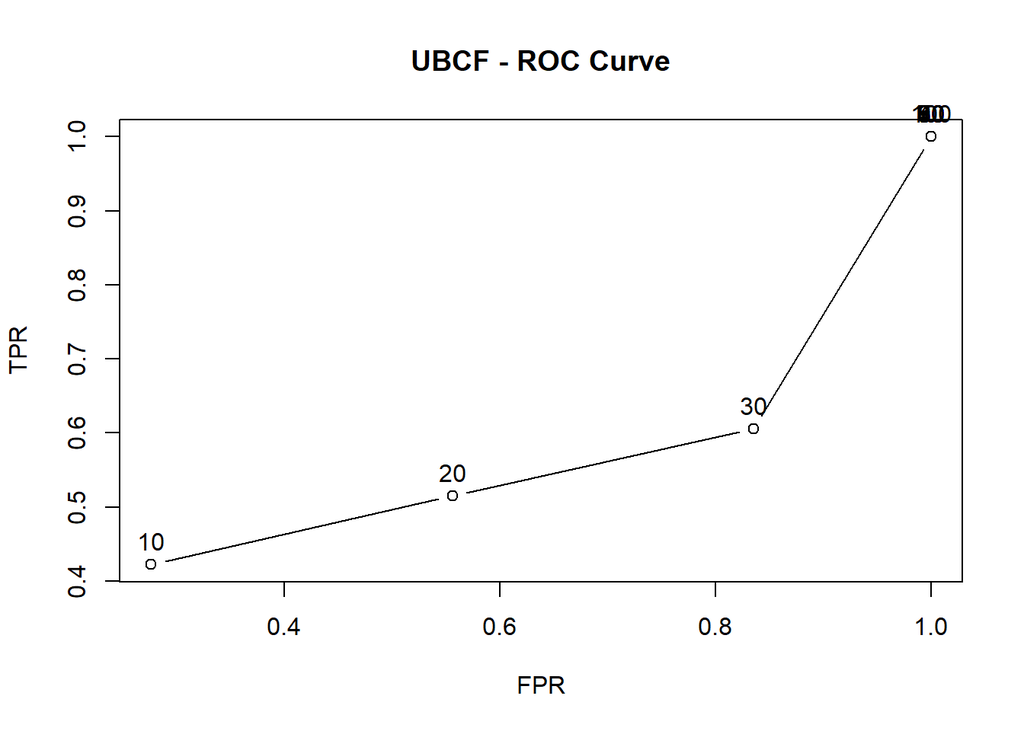

Plot UBCF Precision/recall to verify accuracy

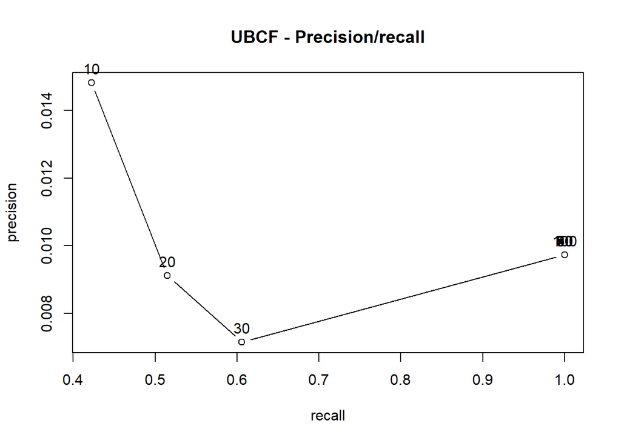

```r
plot(results, "prec/rec",annotate = 1, main = "UBCF - Precision/recall")
```

#### Fine Tuning of the Models to get best results

Lets try different factors to see if we can get a better Precision Recall result. Create UBCF Models with varing vector_nn and different methods i.e.: cosine and pearson.

Determine the best UBCF results based on number of recommendations

# Plot UBCF Models with varing vector_nn and different methods results

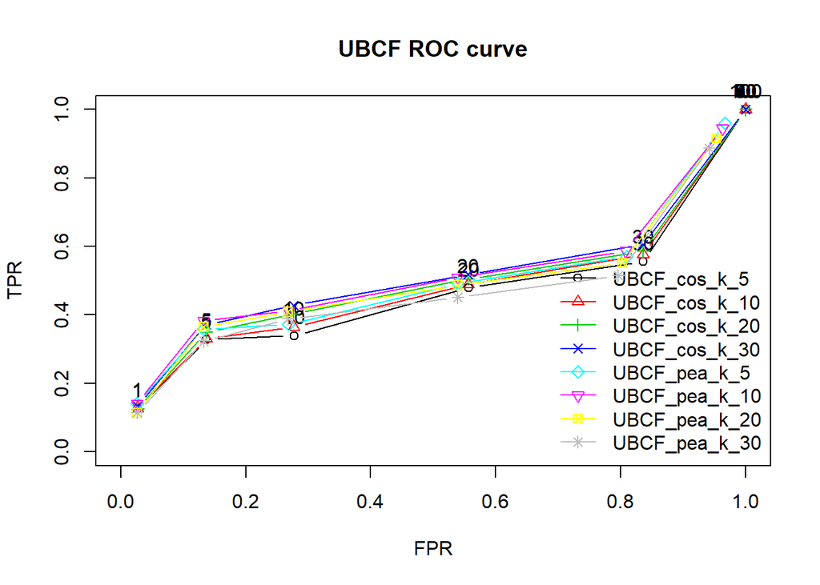

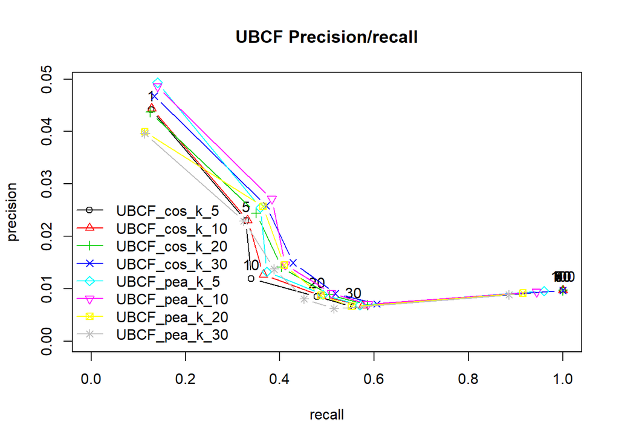

#### Create IBCF Model

# Create IBCF Models with varing vector_kn and different methods i.e.: cosine and pearson

# Get IBCF model results

# Plot IBCF with varing vector_kn and different methods results

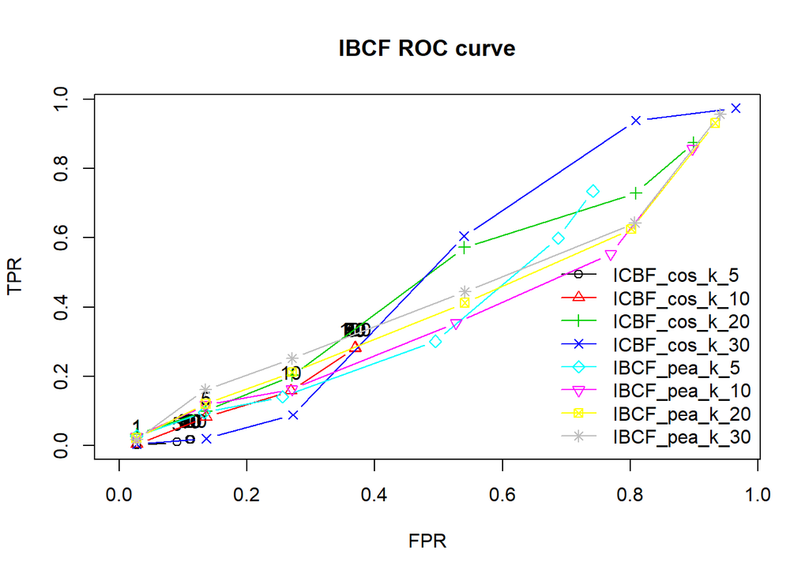

*Note ICBF_pea_k30 appears the best*

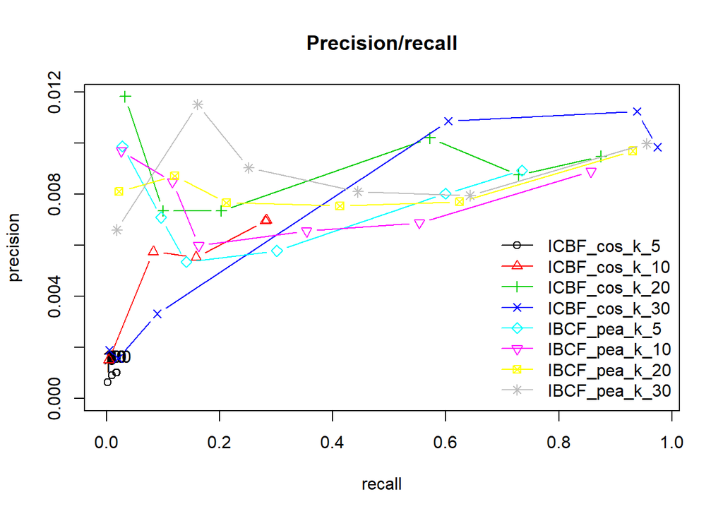